# Biostat 200B Homework 8

Due Mar 15 @ 11:59PM

Author

Ziheng Zhang_606300061

## Question 1

**What differences do you see in the relationships between the SS for A, B and A$*$B for balanced versus unbalanced data?**

### Answer:

Type III SS are SSA, SSB and SSAB are the sums of squares used for testing the null hypotheses that there is no effect of factor A, factor B, or no interaction. These SS are for comparing models with and without that factor (or the interaction).  
Type I SS are sequential; they test for an incremental effect when the term is added to a model including the terms above it.

The results for balanced data are as follows:

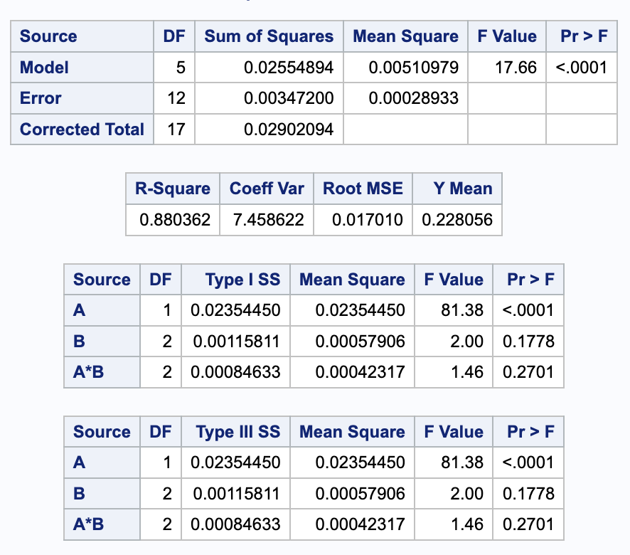

In balanced data, where the cell sizes are equal, the Type I and Type III SS are identical. This is because the factors are uncorrelated predictors. So we can estimate the factor effects independently of one another and estimating the effects of each factor independently yields the same results as estimating them simultaneously in the presence of other factors.

The results for unbalanced data are as follows:

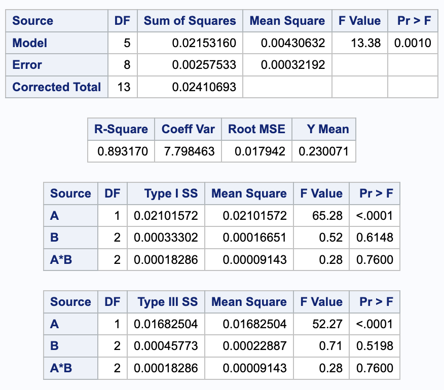

In unbalanced data, where the cell sizes are unequal, the Type I and Type III SS are different. This is because the factors are correlated predictors. Type I SS can vary depending on the order of entry of terms and may not provide a reliable assessment of each factor’s significance. Type III SS provide a more reliable assessment of each factor’s significance and the interaction term, as they compare models with and without each factor (or the interaction), independent of the order of entry of terms.

## Question 3

**Write code and estimate the contrast for comparing the difference between auditory and visual when elapse time is 10 sec to the difference between auditory and visual when elapse time is 15 sec.**

### Answer:

The SAS codes are as follows:

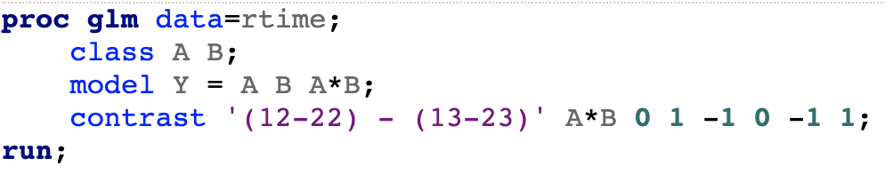

The constrast estimate result is as follows:

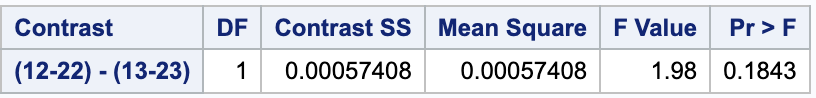

## Question 4

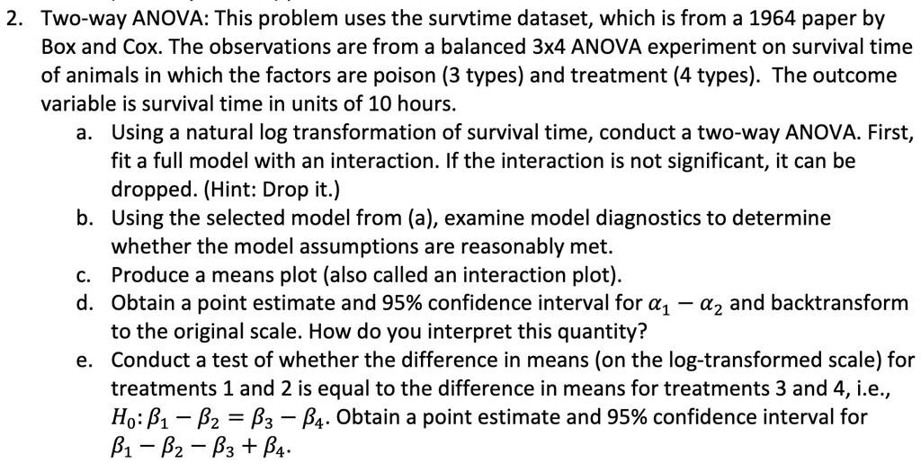

### Answer:

#### a

The SAS codes are as follows:

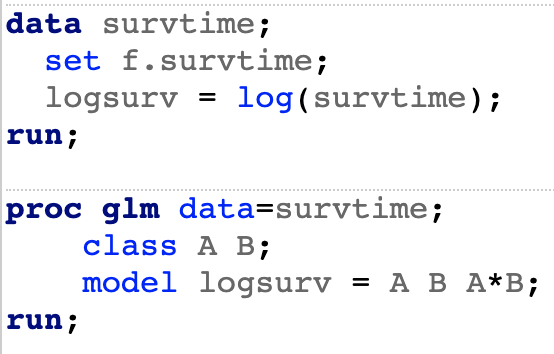

The results are as follows:

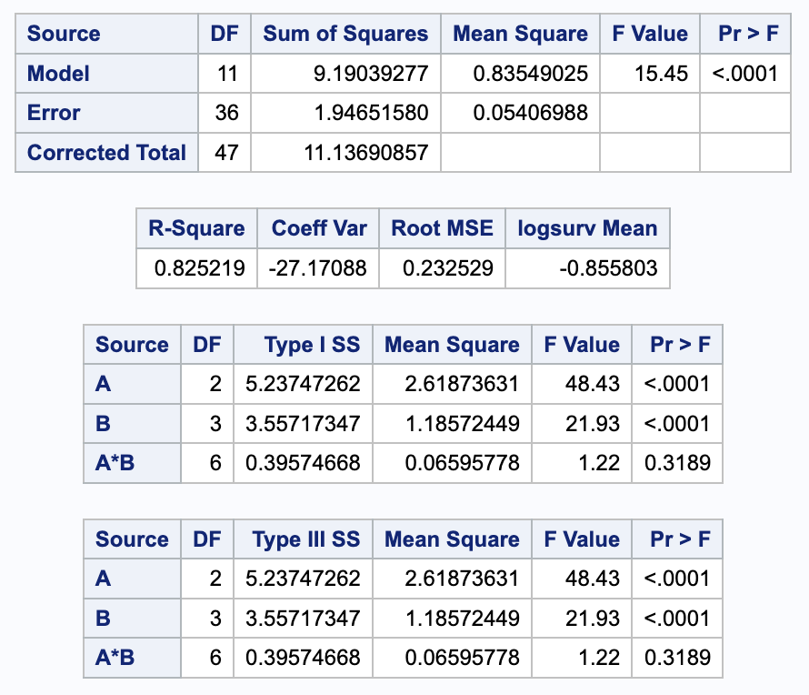

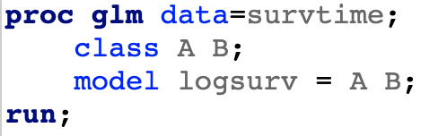

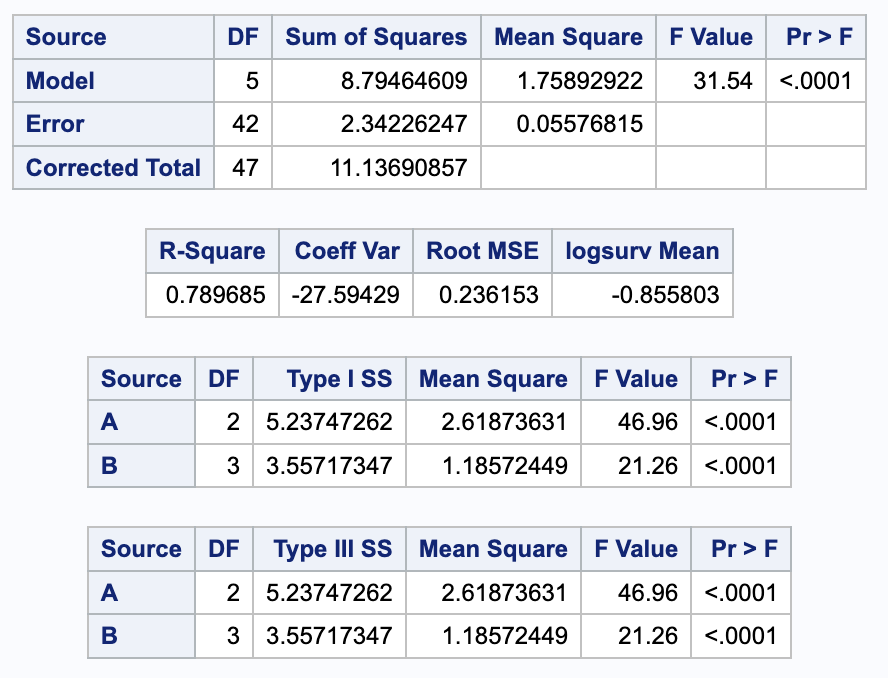

#### b

The SAS codes are as follows:

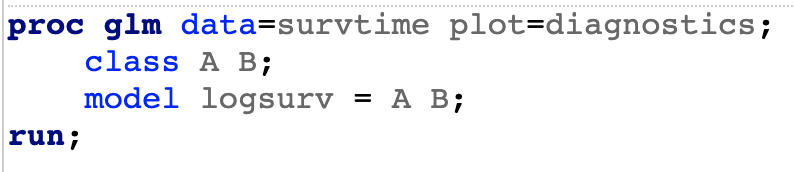

The results are as follows:

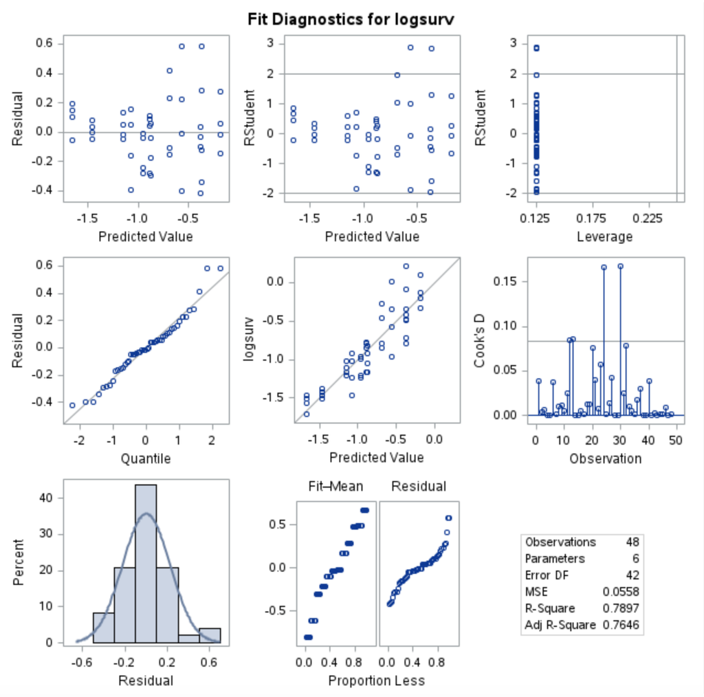

From the plots above, it seems that $E(\epsilon_{i}) = 0$ for all $\textit{i}$ and the residual plot does not show any special pattern. And the error variance are roughly constant across all observations. Also, from QQ plot, all points roughly follow a straight line. So the model assumptions are reasonably met.

#### c

The interaction plot is as follows:

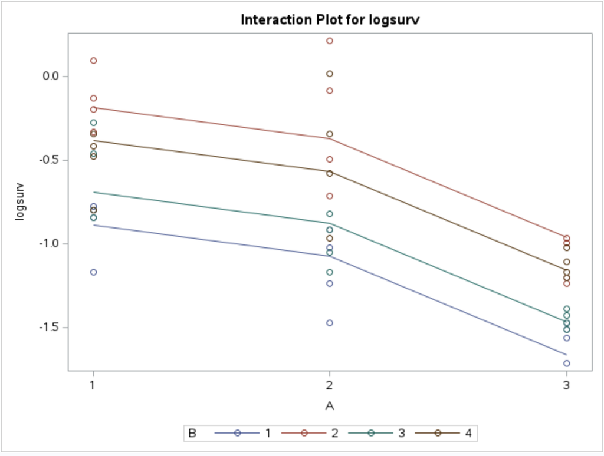

From the interaction plot, we can see that the interaction between `poison` and `treatment` is not significant. The lines for different levels of `treatment` are roughly parallel. This indicates that the interaction between `poison` and `treatment` is not significant and the effects of the two factors are almost additive.

#### d

The SAS codes are as follows:

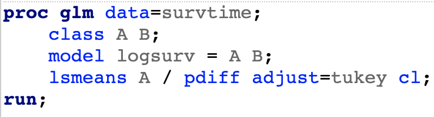

The results are as follows:

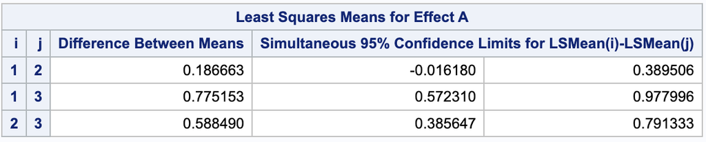

#### e

The SAS codes are as follows:

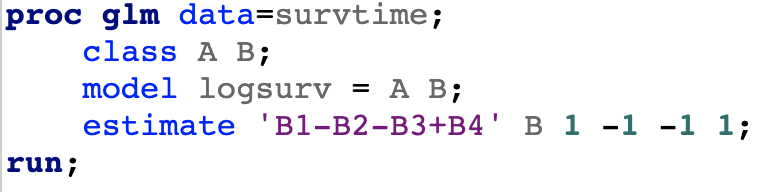

The results are as follows:

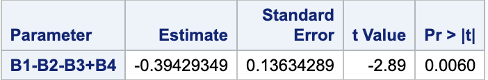

So the point estimate for $\beta_{1}-\beta_{2}-\beta_{3}+\beta_{4}$ is $-0.3943$, standard error is $0.1363$, the t-statistic is $-2.89$ and the p-value is $0.006<0.05$. So we reject the null hypothesis and conclude that there is significant evidence that the difference in means (on the log-transformed scale) for `treatment` 1 and 2 is not equal to the difference in means for `treatment` 3 and 4.

The $95\%$ confidence interval for $\beta_{1}-\beta_{2}-\beta_{3}+\beta_{4}$ is
$$\begin{align*}
&(-0.3943-t_{0.975, 42}*0.1363, -0.3943+t_{0.975, 42}*0.1363)\\
&= (-0.3943-2.018*0.1363, -0.3943+2.018*0.1363)\\
&= (-0.669, -0.119)
\end{align*}$$
where degree of freedom is $N-a-b+1 = 48-4-3+1 = 42$.

## Question 5

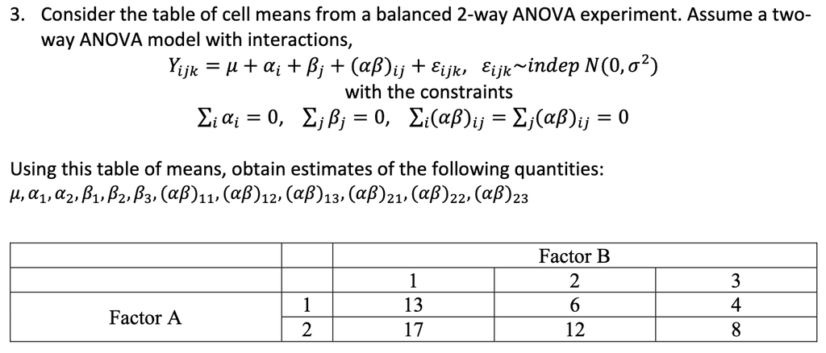

### Answer:

The table of means can be interpreted as follows:

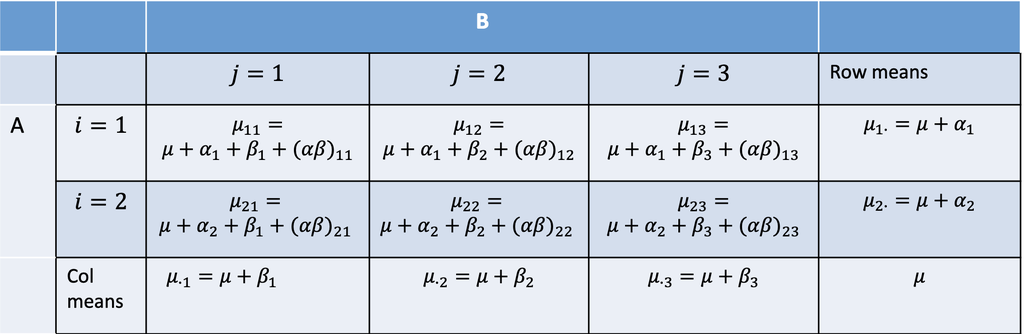

So the estimates of row means are $\bar{Y}_{1..} = \frac{23}{3}$ and $\bar{Y}_{2..} = \frac{37}{3}$. The estimates of column means are $\bar{Y}_{.1.} = 15$, $\bar{Y}_{.2.} = 9$ and $\bar{Y}_{.3.} = 6$. The estimate of the pooled mean is $\bar{Y_{...}}=10$.

So the estimates of these quantities are as follows:

| Parameter | Estimate | Estimate Value |
| --- | --- | --- |
| $\mu$ | $\bar{Y}_{...}$ | $\phantom{-}10$ |
| $\alpha_{1}$ | $\bar{Y}_{1..}-\bar{Y}_{...}$ | $-\frac{7}{3}$ |
| $\alpha_{2}$ | $\bar{Y}_{2..}-\bar{Y}_{...}$ | $\phantom{-}\frac{7}{3}$ |
| $\beta_{1}$ | $\bar{Y}_{.1.}-\bar{Y}_{...}$ | $\phantom{-}5$ |
| $\beta_{2}$ | $\bar{Y}_{.2.}-\bar{Y}_{...}$ | $-1$ |
| $\beta_{3}$ | $\bar{Y}_{.3.}-\bar{Y}_{...}$ | $-4$ |
| $(\alpha\beta)_{11}$ | $\bar{Y}_{11.}-(\bar{Y}_{1..}+\bar{Y}_{.1.}-\bar{Y}_{...})$ | $\phantom{-}\frac{1}{3}$ |
| $(\alpha\beta)_{12}$ | $\bar{Y}_{12.}-(\bar{Y}_{1..}+\bar{Y}_{.2.}-\bar{Y}_{...})$ | $-\frac{2}{3}$ |
| $(\alpha\beta)_{13}$ | $\bar{Y}_{13.}-(\bar{Y}_{1..}+\bar{Y}_{.3.}-\bar{Y}_{...})$ | $\phantom{-}\frac{1}{3}$ |
| $(\alpha\beta)_{21}$ | $\bar{Y}_{21.}-(\bar{Y}_{2..}+\bar{Y}_{.1.}-\bar{Y}_{...})$ | $-\frac{1}{3}$ |
| $(\alpha\beta)_{22}$ | $\bar{Y}_{22.}-(\bar{Y}_{2..}+\bar{Y}_{.2.}-\bar{Y}_{...})$ | $\phantom{-}\frac{2}{3}$ |
| $(\alpha\beta)_{23}$ | $\bar{Y}_{23.}-(\bar{Y}_{2..}+\bar{Y}_{.3.}-\bar{Y}_{...})$ | $-\frac{1}{3}$ |